# QC, Figure S3

# 1 Overview

This document reproduces the expanded quality control analysis across all seven MiSeq runs, generates Figure S3 and companion QC tables, and evaluates ZymoBIOMICS mock community reproducibility across sequencing runs.

**Input:** `data/FigS_3_data.RData` — a pre-built phyloseq object (`qc_ps`) containing 417 genera × 1148 libraries as integer counts, already purged of plant/host sequences.

**Outputs:** - `outputs/FigS_3_expanded_QC.pdf` and `.tiff` — the QC figure - `outputs/TableS_D_control_library_QC.csv` — per-run control summary - `outputs/TableS_I_positive_control_libraries.csv` — per-library positive-control data - Mock community reproducibility statistics

# 2 Configuration and Dependencies

```r
SEED         <- 20260716   # rarefaction / sampling seed
PC_DEPTH     <- NULL       # NULL = rarefy to minimum depth among positives
STUDY_DEPTH  <- 11070      # depth for biological-variation comparison
N_STUDY      <- 200        # number of study samples to draw
FOCAL_GENUS  <- "Bacteroides"
MATERNAL_RUN <- "DI22R28"  # run carrying all maternal samples
MATERNAL_PLATE <- "p18"    # plate within DI22R28 with maternal samples
RESTORE_MOCK <- TRUE      # set TRUE to include mock community in depth panel

need <- c("phyloseq", "vegan", "ggplot2", "patchwork", "dplyr")
```

```r
suppressMessages({
  library(phyloseq)
  library(vegan)
  library(ggplot2)
  library(patchwork)
  library(dplyr)
})
```

# 3 Data Loading and Validation

Load the phyloseq object, verify structure, and confirm no plant/host contaminants remain.

```r
DATA   <- "data/FigS_3_data.RData"
OUTDIR <- "outputs"

e <- new.env()
loaded <- load(DATA, envir = e)

if (!"qc_ps" %in% loaded) {
  stop(DATA, " does not contain object 'qc_ps' (found: ", paste(loaded, collapse = ", "), ")")
}

qc_ps <- e$qc_ps
stopifnot(inherits(qc_ps, "phyloseq"))

cat("Loaded:", basename(DATA), "-", ntaxa(qc_ps), "genera x", nsamples(qc_ps), "libraries\n")
```

```
## Loaded: FigS_3_data.RData - 417 genera x 1148 libraries
```

```r
M   <- as(otu_table(qc_ps), "matrix")
if (!taxa_are_rows(qc_ps)) M <- t(M)

smd <- data.frame(sample_data(qc_ps)@.Data, stringsAsFactors = FALSE)
names(smd) <- sample_variables(qc_ps)
rownames(smd) <- sample_names(qc_ps)

req <- c("run", "plate", "library_class", "depth", "Source")
if (!all(req %in% names(smd))) {
  stop("sample_data missing: ", paste(setdiff(req, names(smd)), collapse = ", "))
}

if (any(M %% 1 != 0)) warning("counts are not integers — rarefaction may be invalid.")

bad <- grep("chloroplast|mitochondri|streptophyt|cyanobacteri", rownames(M), ignore.case = TRUE, value = TRUE)
if (length(bad)) stop("plant/host taxa present: ", paste(bad, collapse = ", "))

RUNS <- sort(unique(smd$run))
cat("Runs:", paste(RUNS, collapse = ", "), "\n")
```

```
## Runs: DI22R01, DI22R02, DI22R03, DI22R04, DI22R05, DI22R06, DI22R28
```

```r
kable(as.data.frame(table(smd$library_class)),
      col.names = c("Library class", "Count"), caption = "Sample counts by library class")
```

Sample counts by library class

| Library class | Count |
| --- | --- |
| Mock community | 13 |
| Negative control | 21 |
| other | 49 |
| Positive control | 14 |
| Runella slithyformis | 14 |
| Study sample | 1037 |

## 3.1 Helper functions

```r
rare_rel <- function(sids, depth = NULL, seed = SEED) {
  sub <- M[, sids, drop = FALSE]
  sub <- sub[rowSums(sub) > 0, , drop = FALSE]
  if (is.null(depth)) depth <- min(colSums(sub))
  if (any(colSums(sub) < depth)) stop("depth exceeds smallest library")
  set.seed(seed)
  r <- t(vegan::rrarefy(t(sub), sample = depth))
  attr(r, "depth") <- depth
  sweep(r, 2, colSums(r), "/")
}

getrow <- function(mat, g) {
  if (g %in% rownames(mat)) mat[g, ] else setNames(rep(0, ncol(mat)), colnames(mat))
}

short <- function(x) sub("^DI22", "", x)
```

# 4 Panel A — *Bacteroides* in Identical Positive-Control DNA

The same faecal DNA positive control was sequenced across all seven runs. We rarefy each set of positive controls to their minimum depth, then compute the relative abundance of *Bacteroides*. DI22R28 (which carries all maternal samples) is highlighted to test whether its *Bacteroides* recovery deviates from other runs.

```r
pc  <- smd %>% filter(library_class == "Positive control")
pcR <- rare_rel(rownames(pc), depth = PC_DEPTH)
PCD <- attr(pcR, "depth")

pcb <- data.frame(
  run = pc$run, plate = pc$plate, raw_reads = pc$depth,
  Bacteroides = 100 * getrow(pcR, FOCAL_GENUS),
  row.names = NULL
) %>% mutate(
  grp = ifelse(run == MATERNAL_RUN,
                paste0(MATERNAL_RUN, " (carries all mothers)"), "Other runs"),
  run_short = short(run)
)

gmean <- mean(pcb$Bacteroides)
ref   <- pcb %>% group_by(run) %>% summarise(m = mean(Bacteroides), .groups = "drop")
oth   <- ref$m[ref$run != MATERNAL_RUN]
z28   <- (ref$m[ref$run == MATERNAL_RUN] - mean(oth)) / sd(oth)

cat("Rarefied to", PCD, "reads\n")
```

```
## Rarefied to 21149 reads
```

```r
kable(ref %>% rename(mean_bacteroides = m),
      col.names = c("MiSeq run", "Mean Bacteroides (%)"),
      caption = sprintf("Per-run mean *Bacteroides* in positive controls (rarefied to %d reads). Cross-run mean: %.2f%%. z of DI22R28 vs other runs: %+.2f", PCD, gmean, z28))
```

Per-run mean *Bacteroides* in positive controls (rarefied to 21149 reads). Cross-run mean: 8.63%. z of DI22R28 vs other runs: -0.30

| MiSeq run | Mean Bacteroides (%) |
| --- | --- |
| DI22R01 | 9.404700 |
| DI22R02 | 8.274623 |
| DI22R03 | 7.688307 |
| DI22R04 | 10.560783 |
| DI22R05 | 7.697763 |
| DI22R06 | 8.418838 |
| DI22R28 | 8.338456 |

## 4.1 Panel A plot

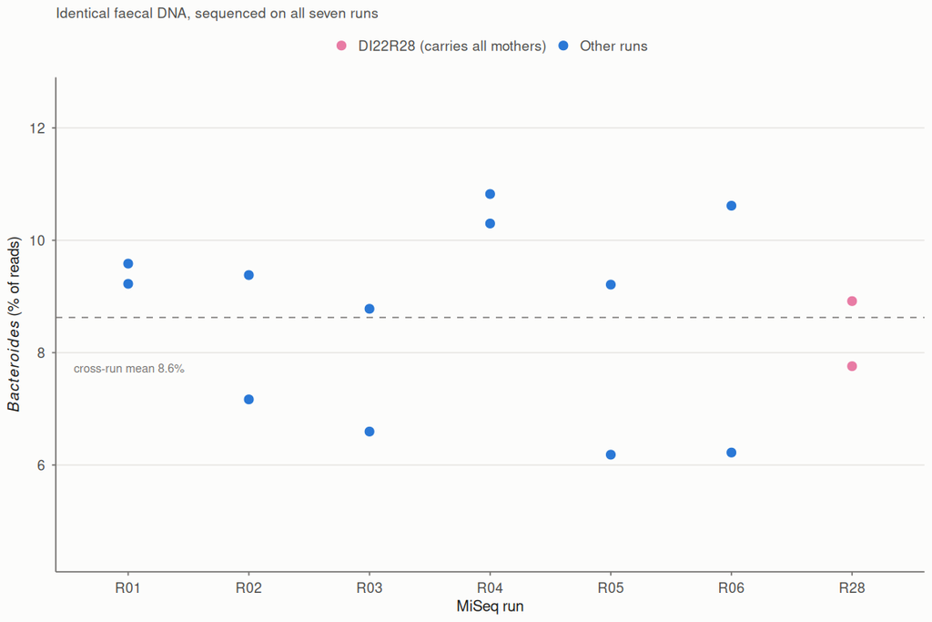

```r
PAL     <- c(blue = "#2a78d6", amber = "#eda100", pink = "#e87ba4")
INK     <- c(primary = "#1a1a19", secondary = "#4a4a48", muted = "#767472")
GRIDCOL <- "#e6e4e1"
SURFACE <- "#fcfcfb"

theme_pub <- function(base = 7) {
  theme_minimal(base_size = base, base_family = "Helvetica") +
    theme(
      panel.grid.minor = element_blank(),
      panel.grid.major = element_line(colour = GRIDCOL, linewidth = 0.25),
      panel.background = element_rect(fill = SURFACE, colour = NA),
      plot.background  = element_rect(fill = SURFACE, colour = NA),
      axis.line   = element_line(colour = INK["muted"], linewidth = 0.3),
      axis.ticks  = element_line(colour = INK["muted"], linewidth = 0.3),
      axis.text   = element_text(colour = INK["secondary"], size = base - 0.5),
      axis.title  = element_text(colour = INK["primary"], size = base),
      plot.title    = element_text(colour = INK["primary"], size = base + 1, face = "bold"),
      plot.subtitle = element_text(colour = INK["secondary"], size = base - 0.5),
      legend.text  = element_text(colour = INK["secondary"], size = base - 0.5),
      legend.key.size = unit(3, "mm")
    )
}

ggplot(pcb, aes(run_short, Bacteroides, colour = grp)) +
  geom_hline(yintercept = gmean, linetype = "dashed", colour = INK["muted"], linewidth = 0.25) +
  geom_point(size = 1.6, stroke = 0.4) +
  annotate("text", x = 0.55, y = gmean - 0.9, hjust = 0, size = 1.9,
           colour = INK["muted"], label = sprintf("cross-run mean %.1f%%", gmean)) +
  scale_colour_manual(
    values = setNames(c(PAL[["pink"]], PAL[["blue"]]),
                      c(paste0(MATERNAL_RUN, " (carries all mothers)"), "Other runs")),
    name = NULL
  ) +
  scale_y_continuous(limits = c(floor(min(pcb$Bacteroides)) - 1.5, ceiling(max(pcb$Bacteroides)) + 1.5)) +
  labs(x = "MiSeq run", y = expression(italic(Bacteroides) * " (% of reads)"),
       subtitle = "Identical faecal DNA, sequenced on all seven runs") +
  theme_pub() +
  theme(panel.grid.major.x = element_blank(), legend.position = "top")
```

# 5 Panel B — Technical vs Biological Variation

We compare Bray-Curtis dissimilarity among replicate positive controls (technical variation) against dissimilarity among randomly drawn study samples (biological variation).

```r
d_pc <- as.matrix(vegdist(t(pcR), "bray"))

bio  <- rownames(smd)[smd$library_class == "Study sample" & smd$Source == "FEC" & smd$depth >= STUDY_DEPTH]
set.seed(1)
bio <- sample(bio, min(N_STUDY, length(bio)))
d_bio <- as.matrix(vegdist(t(rare_rel(bio, depth = STUDY_DEPTH)), "bray"))

med_technical <- median(d_pc[upper.tri(d_pc)])
med_biological <- median(d_bio[upper.tri(d_bio)])

cat("Median technical BC:", sprintf("%.3f", med_technical), "\n")
```

```
## Median technical BC: 0.079
```

```r
cat("Median biological BC:", sprintf("%.3f", med_biological), "\n")
```

```
## Median biological BC: 0.549
```

```r
cat("Ratio: technical is ~", sprintf("%.1f", med_biological / med_technical), "x smaller\n")
```

```
## Ratio: technical is ~ 6.9 x smaller
```

## 5.1 PERMANOVA — does run explain positive-control composition?

```r
set.seed(42)
adonis2(as.dist(d_pc) ~ run, data = pc, permutations = 999)
```

|  | Df | SumOfSqs | R2 | F | Pr(>F) |
| --- | --- | --- | --- | --- | --- |
| Model | 6 | 0.0195543 | 0.4207826 | 0.8475453 | 0.662 |
| Residual | 7 | 0.0269170 | 0.5792174 | NA | NA |
| Total | 13 | 0.0464713 | 1.0000000 | NA | NA |

## 5.2 Panel B plot

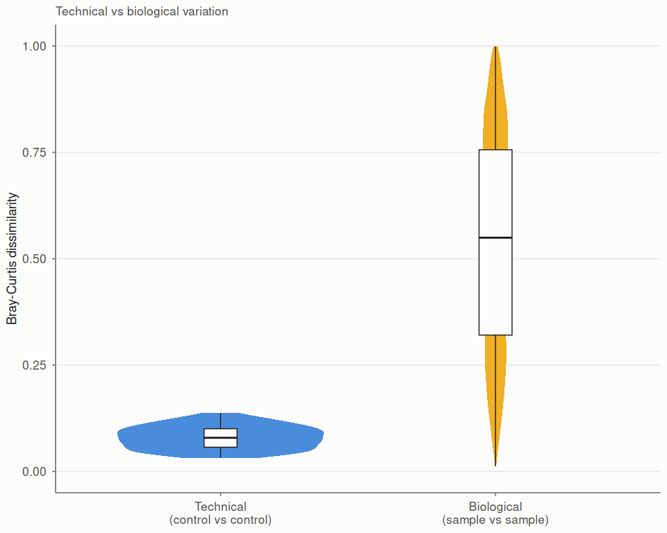

```r
bc <- rbind(
  data.frame(bc = d_pc[upper.tri(d_pc)],   src = "Technical\n(control vs control)"),
  data.frame(bc = d_bio[upper.tri(d_bio)], src = "Biological\n(sample vs sample)")
)
bc$src <- factor(bc$src, levels = c("Technical\n(control vs control)", "Biological\n(sample vs sample)"))

ggplot(bc, aes(src, bc, fill = src)) +
  geom_violin(colour = NA, width = 0.75, alpha = 0.85) +
  geom_boxplot(width = 0.12, outlier.shape = NA, fill = SURFACE, colour = INK["primary"], linewidth = 0.25) +
  scale_fill_manual(values = c(PAL[["blue"]], PAL[["amber"]]), guide = "none") +
  scale_y_continuous(limits = c(0, 1)) +
  labs(x = NULL, y = "Bray-Curtis dissimilarity", subtitle = "Technical vs biological variation") +
  theme_pub() +
  theme(panel.grid.major.x = element_blank())
```

# 6 Panel C — Read Depth by Library Class

Distribution of sequencing depth across all library types. With `RESTORE_MOCK = TRUE`, the mock community is included in this panel.

```r
classes <- c("Study sample", "Positive control", "Runella slithyformis", "Negative control")
if (RESTORE_MOCK) classes <- append(classes, "Mock community", after = 2)

dep <- smd %>% filter(library_class %in% classes) %>%
  mutate(library_class = factor(library_class, levels = rev(classes)))
```

```r
kable(smd %>% filter(library_class %in% classes) %>%
        group_by(library_class) %>%
        summarise(n = n(), median_reads = median(depth), min_reads = min(depth), max_reads = max(depth), .groups = "drop"),
      caption = "Read depth summary by library class")
```

Read depth summary by library class

| library_class | n | median_reads | min_reads | max_reads |
| --- | --- | --- | --- | --- |
| Mock community | 13 | 35586 | 13525 | 60130 |
| Negative control | 21 | 253 | 81 | 1985 |
| Positive control | 14 | 46437 | 21149 | 73211 |
| Runella slithyformis | 14 | 27682 | 8704 | 37434 |
| Study sample | 1037 | 47537 | 40 | 240681 |

## 6.1 Panel C plot

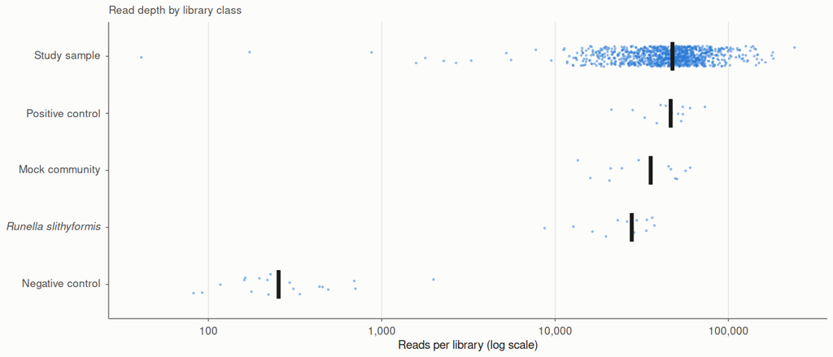

```r
labs_c <- lapply(classes, function(x) {
  if (grepl("Runella", x)) bquote(italic(.(x))) else bquote(.(x))
})

ggplot(dep, aes(depth + 1, library_class)) +
   geom_jitter(position=position_jitter(width=0, height = 0.18, seed = 123),
              size = 0.35, alpha = 0.4, colour = PAL[["blue"]]) +
    stat_summary(fun = median, fun.min = median, fun.max = median, geom = "crossbar",
                 width = 0.5, linewidth = 0.45, colour = INK["primary"], orientation = "y") +
   scale_x_log10(breaks = c(1e2, 1e3, 1e4, 1e5), labels = c("100", "1,000", "10,000", "100,000")) +
   scale_y_discrete(labels = rev(labs_c)) +
   labs(x = "Reads per library (log scale)", y = NULL, subtitle = "Read depth by library class") +
   theme_pub() +
   theme(panel.grid.major.y = element_blank())
```

# 7 Figure Assembly and Export

All three panels are combined with patchwork and exported as publication-ready PDF and TIFF files.

```r
pA_plot <- ggplot(pcb, aes(run_short, Bacteroides, colour = grp)) +
  geom_hline(yintercept = gmean, linetype = "dashed", colour = INK["muted"], linewidth = 0.25) +
  geom_point(size = 1.6, stroke = 0.4) +
  annotate("text", x = 0.55, y = gmean - 0.9, hjust = 0, size = 1.9,
           colour = INK["muted"], label = sprintf("cross-run mean %.1f%%", gmean)) +
  scale_colour_manual(
    values = setNames(c(PAL[["pink"]], PAL[["blue"]]),
                      c(paste0(MATERNAL_RUN, " (carries all mothers)"), "Other runs")), name = NULL) +
  scale_y_continuous(limits = c(floor(min(pcb$Bacteroides)) - 1.5, ceiling(max(pcb$Bacteroides)) + 1.5)) +
  labs(x = "MiSeq run", y = expression(italic(Bacteroides) * " (% of reads)"),
       subtitle = "Identical faecal DNA, sequenced on all seven runs") +
  theme_pub() + theme(panel.grid.major.x = element_blank(), legend.position = "top", legend.margin = margin(b = -4))

pB_plot <- ggplot(bc, aes(src, bc, fill = src)) +
  geom_violin(colour = NA, width = 0.75, alpha = 0.85) +
  geom_boxplot(width = 0.12, outlier.shape = NA, fill = SURFACE, colour = INK["primary"], linewidth = 0.25) +
  scale_fill_manual(values = c(PAL[["blue"]], PAL[["amber"]]), guide = "none") +
  scale_y_continuous(limits = c(0, 1)) +
  labs(x = NULL, y = "Bray-Curtis dissimilarity", subtitle = "Technical vs biological variation") +
  theme_pub() + theme(panel.grid.major.x = element_blank())

pC_plot <- ggplot(dep, aes(depth + 1, library_class)) +
   geom_jitter(position=position_jitter(width=0, height = 0.18, seed = 123),
              size = 0.35, alpha = 0.4, colour = PAL[["blue"]]) +
  stat_summary(fun = median, fun.min = median, fun.max = median, geom = "crossbar",
               width = 0.5, linewidth = 0.45, colour = INK["primary"], orientation = "y") +
  scale_x_log10(breaks = c(1e2, 1e3, 1e4, 1e5), labels = c("100", "1,000", "10,000", "100,000")) +
  scale_y_discrete(labels = rev(labs_c)) +
  labs(x = "Reads per library (log scale)", y = NULL, subtitle = "Read depth by library class") +
  theme_pub() + theme(panel.grid.major.y = element_blank())

fig <- ((pA_plot | pB_plot) + plot_layout(widths = c(1.5, 1))) / pC_plot +
  plot_layout(heights = c(1, 0.72)) +
  plot_annotation(
    tag_levels = "a",
    title = "Expanded quality control across the seven MiSeq runs",
    theme = theme(plot.title = element_text(size = 8, face = "bold", colour = INK["primary"]),
                  plot.background = element_rect(fill = SURFACE, colour = NA)))

ggsave(file.path(OUTDIR, "FigS_3_expanded_QC.pdf"), fig, width = 174, height = 118, units = "mm", device = "pdf")
ggsave(file.path(OUTDIR, "FigS_3_expanded_QC.tiff"), fig, width = 174, height = 118, units = "mm", dpi = 300, compression = "lzw")

cat("Exported Figure S3 to outputs/\n")
```

```
## Exported Figure S3 to outputs/
```

# 8 QC Tables

## 8.1 Table S-D — Per-run Control Library QC

```r
rs <- smd %>% filter(library_class == "Runella slithyformis")
rs_off <- NULL

if (nrow(rs)) {
  rsR  <- rare_rel(rownames(rs))
  RSD <- attr(rsR, "depth")
  rrow <- grep("Runella", rownames(rsR), value = TRUE, ignore.case = TRUE)
  rs_off <- data.frame(run = rs$run,
                        off = 100 * (1 - colSums(rsR[rrow, , drop = FALSE])))
}

## ---- mock community off-target ------------------------------------------------
MOCK_TARGETS <- c("Limosilactobacillus", "Salmonella", "Bacillus",
                  "Escherichia/Shigella", "Staphylococcus", "Pseudomonas",
                  "Listeria", "Enterococcus")

mock_ctrl <- smd %>% filter(library_class == "Mock community")
mock_off  <- NULL

if (nrow(mock_ctrl) >= 2) {
  mockR  <- rare_rel(rownames(mock_ctrl))
  MCD    <- attr(mockR, "depth")
  present <- MOCK_TARGETS[MOCK_TARGETS %in% rownames(mockR)]
  mock_off <- data.frame(run = mock_ctrl$run,
                          off = 100 * (1 - colSums(mockR[present, , drop = FALSE])))
}

neg <- smd %>% filter(library_class == "Negative control")

tabD <- data.frame(MiSeq_run = RUNS) %>%
  left_join(pcb %>% group_by(MiSeq_run = run) %>%
               summarise(PC_n = n(), PC_Bacteroides_pct = round(mean(Bacteroides), 2), .groups = "drop"), by = "MiSeq_run") %>%
  left_join(if (!is.null(rs_off)) rs_off %>% group_by(MiSeq_run = run) %>%
               summarise(Runella_n = n(), Runella_offtarget_pct = round(mean(off), 3), .groups = "drop")
             else data.frame(MiSeq_run = character(), Runella_n = integer(), Runella_offtarget_pct = numeric()), by = "MiSeq_run") %>%
  left_join(if (!is.null(mock_off)) mock_off %>% group_by(MiSeq_run = run) %>%
               summarise(Mock_n = n(), Mock_offtarget_pct = round(mean(off), 3), .groups = "drop")
             else data.frame(MiSeq_run = character(), Mock_n = integer(), Mock_offtarget_pct = numeric()), by = "MiSeq_run") %>%
  left_join(neg %>% group_by(MiSeq_run = run) %>%
               summarise(NC_n = n(), NC_median_reads = median(depth), .groups = "drop"), by = "MiSeq_run") %>%
  left_join(smd %>% filter(library_class == "Study sample") %>%
               group_by(MiSeq_run = run) %>%
               summarise(study_n = n(), study_median_reads = median(depth), .groups = "drop"), by = "MiSeq_run")

kable(tabD, caption = "Per-run control library QC summary (Table S-D)")
```

Per-run control library QC summary (Table S-D)

| MiSeq_run | PC_n | PC_Bacteroides_pct | Runella_n | Runella_offtarget_pct | Mock_n | Mock_offtarget_pct | NC_n | NC_median_reads | study_n | study_median_reads |
| --- | --- | --- | --- | --- | --- | --- | --- | --- | --- | --- |
| DI22R01 | 2 | 9.40 | 2 | 0.006 | 2 | 0.000 | 9 | 253.0 | 163 | 48268.0 |
| DI22R02 | 2 | 8.27 | 2 | 0.011 | 2 | 0.100 | 4 | 156.0 | 154 | 53902.5 |
| DI22R03 | 2 | 7.69 | 2 | 0.029 | 2 | 0.011 | 1 | 227.0 | 139 | 33099.0 |
| DI22R04 | 2 | 10.56 | 2 | 0.011 | 2 | 0.000 | 3 | 254.0 | 142 | 64941.5 |
| DI22R05 | 2 | 7.70 | 2 | 0.023 | 2 | 0.022 | 2 | 300.5 | 161 | 54014.0 |
| DI22R06 | 2 | 8.42 | 2 | 0.011 | 2 | 0.000 | NA | NA | 171 | 24671.0 |
| DI22R28 | 2 | 8.34 | 2 | 0.040 | 1 | 0.695 | 2 | 325.5 | 107 | 40003.0 |

```r
write.csv(tabD, file.path(OUTDIR, "TableS_D_control_library_QC.csv"), row.names = FALSE)
```

## 8.2 Table S-I — Per-library Positive Control Data

```r
tabI <- pcb %>%
  transmute(MiSeq_run = run, plate, raw_reads, rarefied_to = PCD, Bacteroides_pct = round(Bacteroides, 3)) %>%
  arrange(MiSeq_run, plate)

kable(tabI, caption = "Per-library positive control Bacteroides percentages (Table S-I)")
```

Per-library positive control Bacteroides percentages (Table S-I)

| MiSeq_run | plate | raw_reads | rarefied_to | Bacteroides_pct |
| --- | --- | --- | --- | --- |
| DI22R01 | p07 | 28043 | 21149 | 9.584 |
| DI22R01 | p09 | 47083 | 21149 | 9.225 |
| DI22R02 | p14 | 43500 | 21149 | 9.381 |
| DI22R02 | p17 | 53381 | 21149 | 7.168 |
| DI22R03 | p05 | 45791 | 21149 | 6.596 |
| DI22R03 | p12 | 21149 | 21149 | 8.781 |
| DI22R04 | p02 | 38603 | 21149 | 10.823 |
| DI22R04 | p15 | 54505 | 21149 | 10.298 |
| DI22R05 | p08 | 60088 | 21149 | 9.211 |
| DI22R05 | p19 | 51236 | 21149 | 6.185 |
| DI22R06 | p03 | 73211 | 21149 | 10.615 |
| DI22R06 | p16 | 40619 | 21149 | 6.223 |
| DI22R28 | p10 | 54634 | 21149 | 8.918 |
| DI22R28 | p18 | 32837 | 21149 | 7.759 |

```r
write.csv(tabI, file.path(OUTDIR, "TableS_I_positive_control_libraries.csv"), row.names = FALSE)
```

# 9 Legend Values Summary

## 9.1 Panel A — Positive Control

```r
cat("Libraries:", nrow(pcb), "(rarefied to", PCD, "reads)\n")
```

```
## Libraries: 14 (rarefied to 21149 reads)
```

```r
cat("Cross-run mean:", sprintf("%.2f%%", gmean), "\n")
```

```
## Cross-run mean: 8.63%
```

```r
cat("Run means range:", sprintf("%.2f-%.2f%%", min(ref$m), max(ref$m)), "\n")
```

```
## Run means range: 7.69-10.56%
```

```r
cat("Library range:", sprintf("%.1f-%.1f%%", min(pcb$Bacteroides), max(pcb$Bacteroides)), "\n")
```

```
## Library range: 6.2-10.8%
```

```r
cat(MATERNAL_RUN, "mean:", sprintf("%.2f%%", ref$m[ref$run == MATERNAL_RUN]), "z vs other runs =", sprintf("%+.2f", z28), "\n")
```

```
## DI22R28 mean: 8.34% z vs other runs = -0.30
```

```r
cat("Plate", MATERNAL_PLATE, "library:", sprintf("%.2f%%", pcb$Bacteroides[pcb$plate == MATERNAL_PLATE]), "\n")
```

```
## Plate p18 library: 7.76%
```

### 9.1.1 Leave-one-out z for every run

```r
zz <- vapply(ref$run, function(r) {
  o <- ref$m[ref$run != r]
  (ref$m[ref$run == r] - mean(o)) / sd(o)
}, numeric(1))
kable(data.frame(Run = names(zz), Z_score = round(sort(zz), 2)),
      row.names = FALSE, caption = "Leave-one-out z-scores for each run scored against the other six")
```

Leave-one-out z-scores for each run scored against the other six

[output not shown]

## 9.2 Panel B — Dissimilarity

```r
cat("Technical (control vs control), median BC:", sprintf("%.3f", med_technical), "\n")
```

```
## Technical (control vs control), median BC: 0.079
```

```r
cat("Biological (sample vs sample), median BC:", sprintf("%.3f", med_biological), "\n")
```

```
## Biological (sample vs sample), median BC: 0.549
```

```r
cat("Ratio: technical is ~", sprintf("%.1f", med_biological / med_technical), "x smaller\n")
```

```
## Ratio: technical is ~ 6.9 x smaller
```

## 9.3 Panel C — Read Depth & Controls

```r
if (nrow(neg)) {
  cat("Negative controls are",
      sprintf("%.2f", 100 * median(neg$depth) /
                    median(smd$depth[smd$library_class == "Study sample"])),
      "% of median study-sample depth\n", sep = "")
}
```

```
## Negative controls are0.53% of median study-sample depth
```

```r
if (!is.null(rs_off)) {
  cat("\nRunella off-target per run (%; rarefied to", RSD, "reads):\n")
  print(rs_off %>% group_by(run) %>%
          summarise(mean_offtarget_pct = round(mean(off), 3), .groups = "drop"))
}
```

```
##
## Runella off-target per run (%; rarefied to 8704 reads):
## # A tibble: 7 × 2
##   run     mean_offtarget_pct
##   <chr>                <dbl>
## 1 DI22R01              0.006
## 2 DI22R02              0.011
## 3 DI22R03              0.029
## 4 DI22R04              0.011
## 5 DI22R05              0.023
## 6 DI22R06              0.011
## 7 DI22R28              0.04
```

```r
if (!is.null(mock_off)) {
  cat("\nMock off-target per run (%; rarefied to", MCD, "reads):\n")
  print(mock_off %>% group_by(run) %>%
          summarise(mean_offtarget_pct = round(mean(off), 3), .groups = "drop"))
}
```

```
##
## Mock off-target per run (%; rarefied to 13525 reads):
## # A tibble: 7 × 2
##   run     mean_offtarget_pct
##   <chr>                <dbl>
## 1 DI22R01              0
## 2 DI22R02              0.1
## 3 DI22R03              0.011
## 4 DI22R04              0
## 5 DI22R05              0.022
## 6 DI22R06              0
## 7 DI22R28              0.695
```

# 10 Mock Community Reproducibility

Genus-level consistency of ZymoBIOMICS mock communities across all seven sequencing runs.

```r
mock <- smd %>% filter(library_class == "Mock community")
cat("Mock libraries:", nrow(mock), "\n")
```

```
## Mock libraries: 13
```

```r
cat("Runs:", paste(sort(unique(mock$run)), collapse = ", "), "\n")
```

```
## Runs: DI22R01, DI22R02, DI22R03, DI22R04, DI22R05, DI22R06, DI22R28
```

```r
if (nrow(mock) >= 2) {
  mockR <- rare_rel(rownames(mock))
  MCD   <- attr(mockR, "depth")
  cat("Rarefied to:", MCD, "reads\n")
}
```

```
## Rarefied to: 13525 reads
```

## 10.1 Pairwise Pearson Correlation

How consistent are mock profiles across all pairwise comparisons?

```r
if (nrow(mock) >= 2) {
  mock_cor <- cor(mockR, method = "pearson")
  diag(mock_cor) <- NA
  mock_cor_values <- mock_cor[upper.tri(mock_cor)]

  kable(data.frame(
    median = sprintf("%.4f", median(mock_cor_values, na.rm = TRUE)),
    min    = sprintf("%.4f", min(mock_cor_values,   na.rm = TRUE)),
    max    = sprintf("%.4f", max(mock_cor_values, na.rm = TRUE))
  ), caption = "Pairwise Pearson correlation between mock library profiles")
}
```

Pairwise Pearson correlation between mock library profiles

| median | min | max |
| --- | --- | --- |
| 0.9390 | 0.6287 | 0.9992 |

## 10.2 Correlation to Consensus Profile

How similar is each individual mock library to the overall average?

```r
if (nrow(mock) >= 2) {
  mock_consensus <- rowMeans(mockR)
  mock_consistency <- data.frame(
    sample = colnames(mockR),
    correlation_to_consensus = apply(
      mockR, 2, function(x) cor(x, mock_consensus, method = "pearson")))

  kable(mock_consistency, digits = 4,
        caption = sprintf("Correlation of each mock library to the consensus profile. Lowest: %.4f",
                          min(mock_consistency$correlation_to_consensus)))
}
```

Correlation of each mock library to the consensus profile. Lowest: 0.8939

|  | sample | correlation_to_consensus |
| --- | --- | --- |
| DI22R01\|DI22R01p07.H05 | DI22R01\|DI22R01p07.H05 | 0.9907 |
| DI22R01\|DI22R01p09.H05 | DI22R01\|DI22R01p09.H05 | 0.9001 |
| DI22R02\|DI22R02p14.H05 | DI22R02\|DI22R02p14.H05 | 0.9968 |
| DI22R02\|DI22R02p17.H05 | DI22R02\|DI22R02p17.H05 | 0.9086 |
| DI22R03\|DI22R03p05.H05 | DI22R03\|DI22R03p05.H05 | 0.9284 |
| DI22R03\|DI22R03p12.H05 | DI22R03\|DI22R03p12.H05 | 0.9645 |
| DI22R04\|DI22R04p02.H05 | DI22R04\|DI22R04p02.H05 | 0.9689 |
| DI22R04\|DI22R04p15.H05 | DI22R04\|DI22R04p15.H05 | 0.9451 |
| DI22R05\|DI22R05p08.H05 | DI22R05\|DI22R05p08.H05 | 0.9977 |
| DI22R05\|DI22R05p19.H05 | DI22R05\|DI22R05p19.H05 | 0.9329 |
| DI22R06\|DI22R06p03.H05 | DI22R06\|DI22R06p03.H05 | 0.9267 |
| DI22R06\|DI22R06p16.H05 | DI22R06\|DI22R06p16.H05 | 0.8939 |
| DI22R28\|DI22R28p18.H05 | DI22R28\|DI22R28p18.H05 | 0.9959 |

## 10.3 Bray-Curtis Dissimilarity

How different are the overall microbial compositions between mock libraries?

```r
if (nrow(mock) >= 2) {
  mock_bc <- vegdist(t(mockR), method = "bray")

  kable(data.frame(
    median = sprintf("%.4f", median(mock_bc)),
    min    = sprintf("%.4f", min(mock_bc)),
    max    = sprintf("%.4f", max(mock_bc))
  ), caption = "Bray-Curtis dissimilarity between mock library profiles")
}
```

Bray-Curtis dissimilarity between mock library profiles

| median | min | max |
| --- | --- | --- |
| 0.1016 | 0.0172 | 0.2600 |

## 10.4 RDA Ordination (Visualisation)

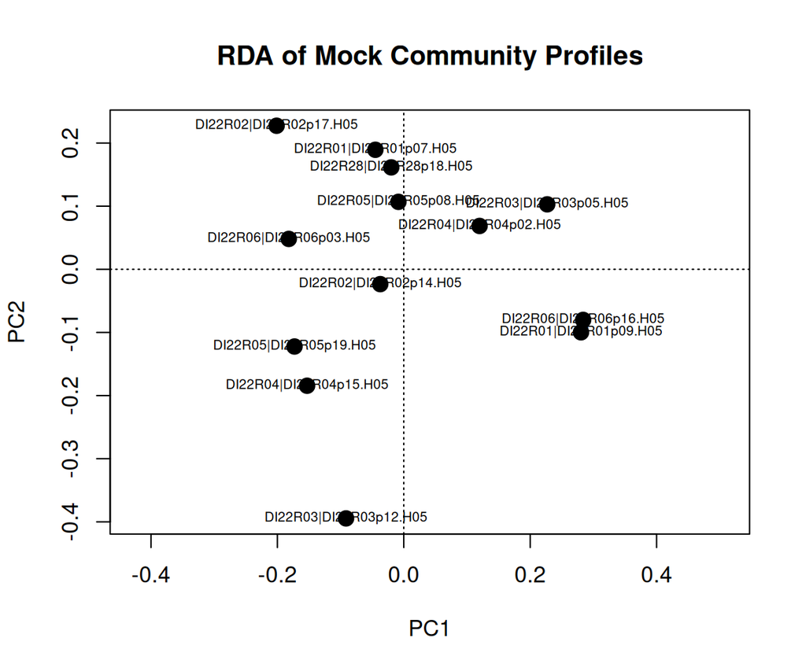

```r
if (nrow(mock) >= 2) {
  ord <- rda(t(mockR))
  plot(ord, display = "sites", type = "n", main = "RDA of Mock Community Profiles")
  points(ord, display = "sites", pch = 19, cex = 1.5)
  text(ord, display = "sites", cex = 0.6)
}
```

# 11 Session Information

```r
cat(R.version.string, "\n")
```

```
## R version 4.5.1 (2025-06-13)
```

```r
for (p in need) cat(sprintf("  %-12s %s\n", p, as.character(packageVersion(p))))
```

```
##   phyloseq     1.54.0
##   vegan        2.7.2
##   ggplot2      4.0.1
##   patchwork    1.3.2
##   dplyr        1.1.4
```

```r
cat("seed:", SEED, "\n")
```

```
## seed: 20260716
```